# MEDB 5501, Module04

2024-09-10

## Topics to be covered

- What you will learn
  - Scatterplots and correlations
  - Boxplots and effect sizes
  - R code for scatterplots and boxplots
  - Bar plots for categorical outcomes
  - R code for bar plots

## Assessing relationships (bivariate statistics), 1

- Between two continuous variables
  - Scatterplot
  - Correlation

## Assessing relationships (bivariate statistics), 2

- Between a categorical and a continuous variable
  - Boxplot
  - Effect size

## Assessing relationships (bivariate statistics), 3

- Between two categorical variables
  - Bar plots
  - Many numeric measures (covered later)

## Scatterplot

- Assess relationship between two continuous variables
  - Outcome on y-axis
  - Exposure/intervention on x-axis

## Patterns on a scatterplot

- Strong, weak, or no relationship
- Direction of relationship
- Nonlinear patterns
  - Diminishing returns
  - Exponential acceleration
  - Hormesis

## Covariance

- $Cov(X, Y) = \frac{\Sigma (X_i-\bar{X})(Y_i-\bar{Y})}{n-1}$
  - $X_i > \bar{X}$ and $Y_i > \bar{Y};\ \ \$ (+) $\times$ (+) = +
  - $X_i < \bar{X}$ and $Y_i < \bar{Y};\ \ \$ (-) $\times$ (-) = +
  - $X_i > \bar{X}$ and $Y_i < \bar{Y};\ \ \$ (+) $\times$ (-) = -
  - $X_i < \bar{X}$ and $Y_i > \bar{Y};\ \ \$ (-) $\times$ (+) = -

## The correlation coefficient, 1

- $r = Corr(X, Y) = \frac{Cov(X, Y)}{S_X S_y}$
  - r is always between -1 and +1.
  - r is a unitless quantity

## The correlation coefficient, 2

- Informal interpretation
  - +0.7 < r < +1.0 is a strong positive relationship
  - +0.3 < r < +0.7 is a weak positive relationship
  - -0.3 < r < +0.3 is little or no relationship
  - -0.7 < r < -0.3 is a weak negative relationship
  - -1.0 < r < -0.7 is a strong negative relationship

## An example of a strong positive relationship

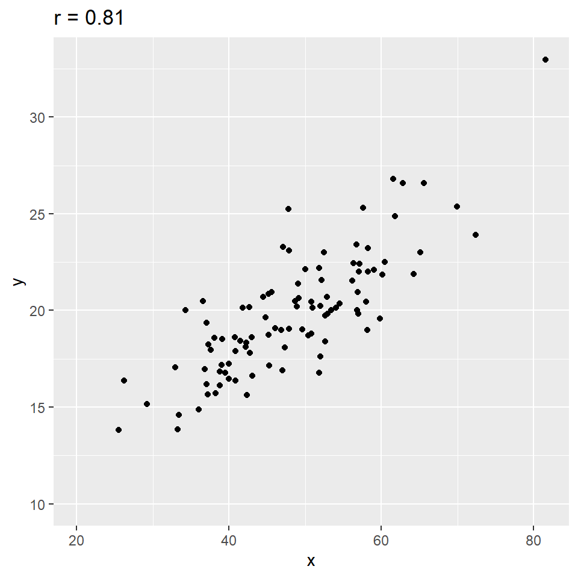

## An example of a weak positive relationship

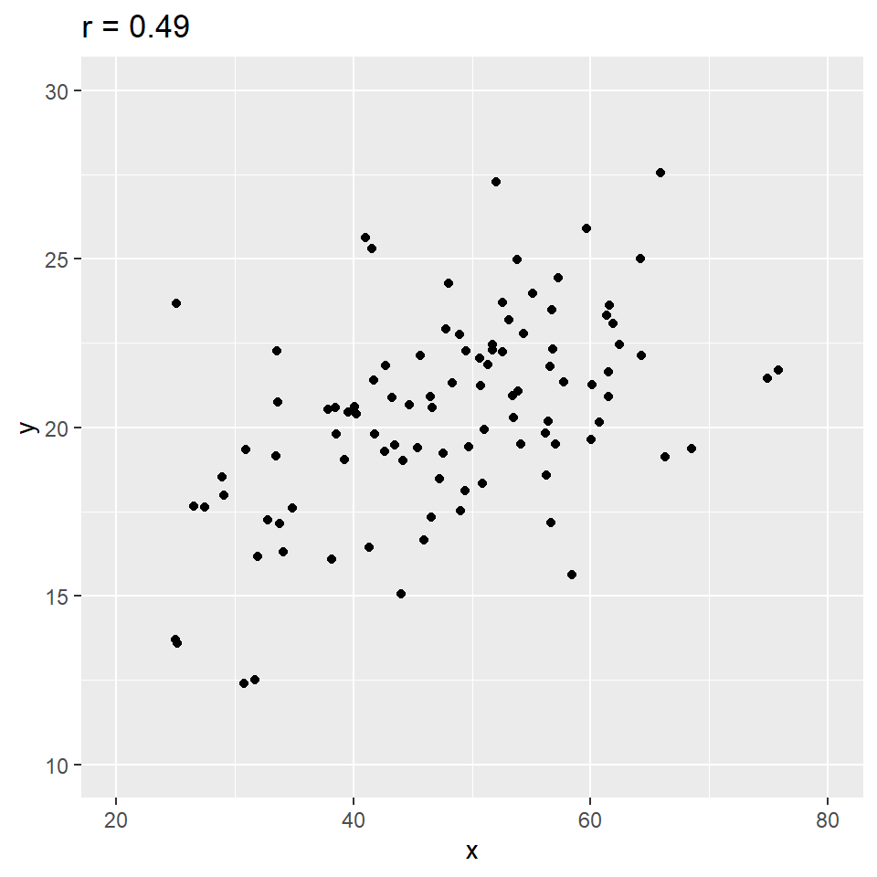

## An example of a little or no relationship

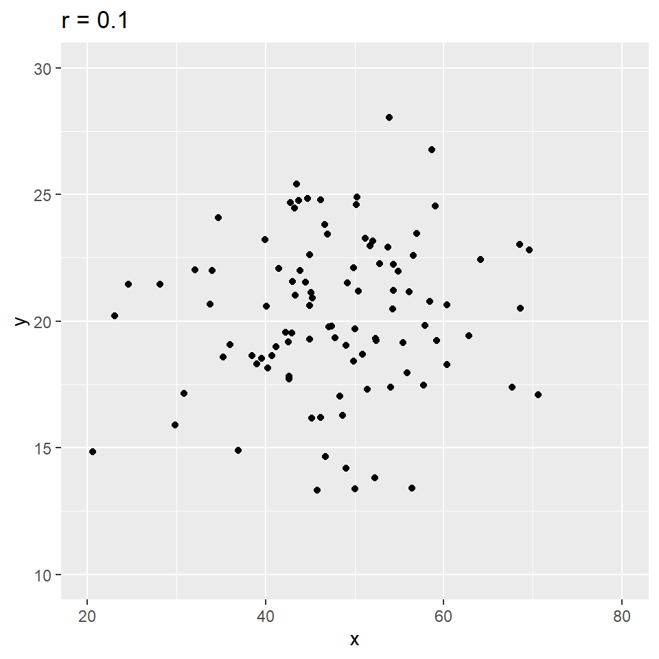

## An example of a weak negative relationship

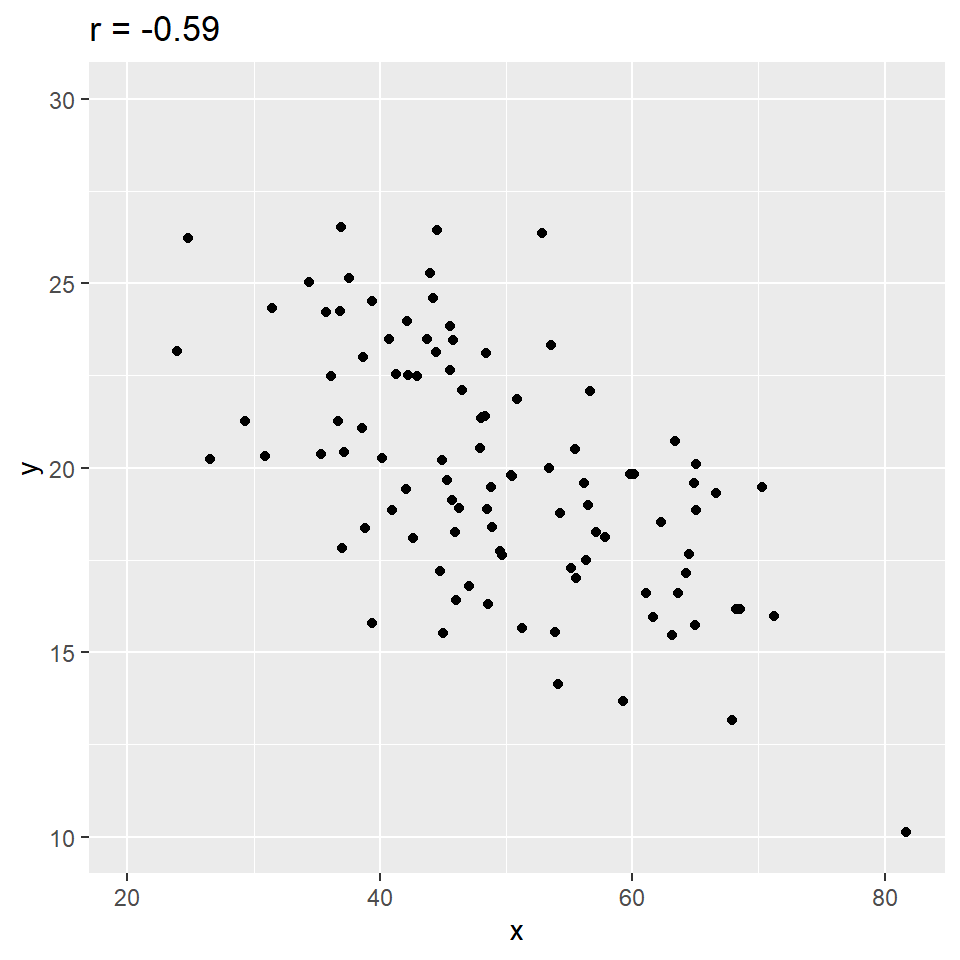

## An example of a strong negative relationship

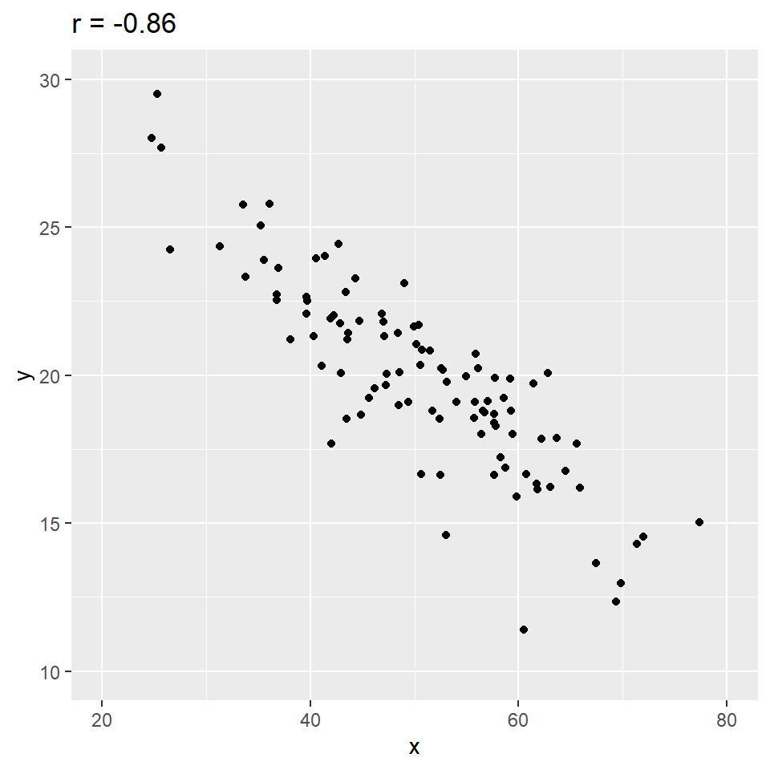

## Break #1

- What you have learned
  - Scatterplots and correlations
- What’s coming next
  - Boxplots and effect sizes

## Boxplots

- Five number summary
  - Min, 25%, 50%, 75%, Max
- Assess relationship between categorical and continuous outcome.
  - One boxplot for each category
- Look for shift from one boxplot to another
  - Also changes in variation

## Effect size, 1

- $ES = \frac{\bar{X}_1-\bar{X}_2}{S}$
  - Different choices for S
  - $S_1$, $S_2$, or $S_p$
- Also known as standardized mean difference (SMD)

## Effect size, 1

- Interpretation (controversial!)
  - Small: ES = 0.2
    - Height difference between 15 and 16 year old girls
  - Medium: ES = 0.5
    - Height difference between 14 and 18 year old girls
  - Large: ES = 0.8
    - Height difference between 13 and 18 year old girls

## Uses of the effect size

- Input statistic for systematic overviews/meta-analyses
- Intermediate endpoint in power and sample size calculations
- Direct estimate of power and sample size (NO!!)
- Gauging the practical significance of a research study (NO!!)

## Criticisms of the effect size

- Sample size calculations need three things
  - Research hypothesis
  - Variation of the outcome measure
  - Minimum clinically important difference (MCID)
    - Unitless quantities have no clinical meaning
- Small, medium, large vary across disciplines
- Provide cover for arbitrary sample size choices
  - You must consider variation and MCID separately

## Example of a large effect size

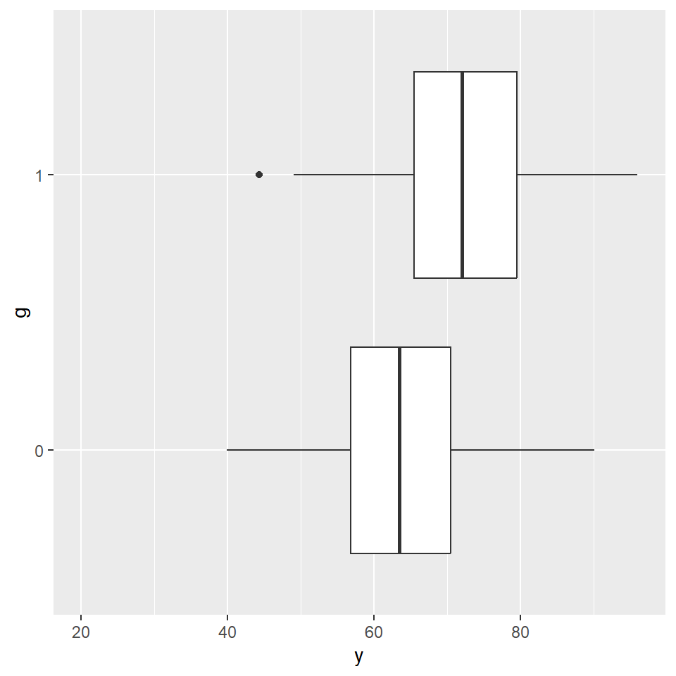

## Example of a medium effect size

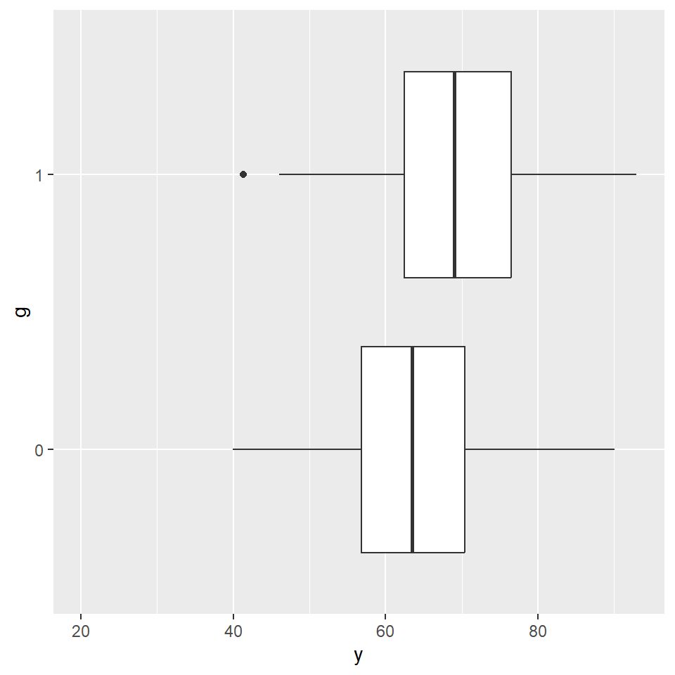

## Example of a small effect size

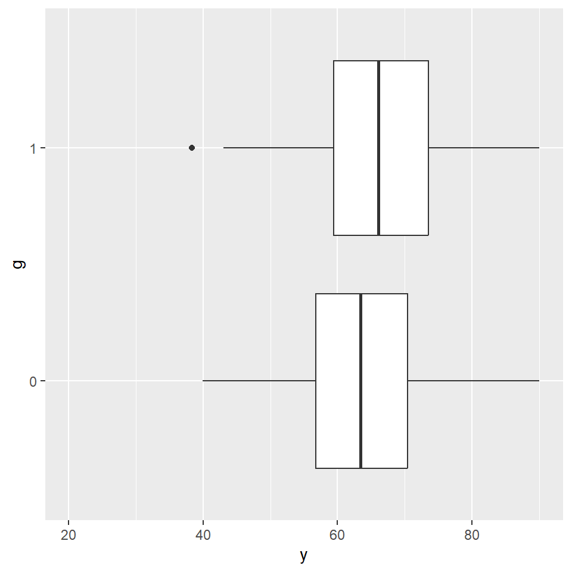

## Break #2

- What you have learned
  - Boxplots and effect sizes
- What’s coming next
  - R code for scatterplots and boxplots

## Data dictionary for fev, 1

```
---
data_dictionary: fev (.csv, sas7bdat, .sav, .txt)
```

```
copyright: >
  The author of the jse article holds the copyright, but does not list
  conditions under which it can be used. Individual use for educational
  purposes is probably permitted under the Fair Use provisions of
  U.S. Copyright laws.
```

```
description: >
  Forced Expiratory Volume (FEV) in children. The data was collected
  in Boston in the 1970s.
```

```
additional_description:
  https://jse.amstat.org/v13n2/datasets.kahn.html
  https://jse.amstat.org/datasets/fev.txt
```

## Data dictionary for fev, 2

```
download_url:
  https://jse.amstat.org/datasets/fev.dat.txt
```

```
format:
  csv: comma delimited
  sas7bdat: proprietary (SAS)
  sav: proprietary (SPSS)
  txt: fixed width
```

```
varnames:
  not included
```

```
missing_value_code:
  not needed
```

```
size:
  rows: 654
  columns: 5
```

## Data dictionary for fev, 3

```
vars:
  age:
    scale: ratio
    range: positive integer
    unit: years
```

```
  fev:
    label: Forced Expiratory Volume
    scale: ratio
    range: positive real
    unit: liters
```

## Data dictionary for fev, 4

```
  ht:
    label: Height
    scale: positive real
    unit: inches
```

```
  sex:
    value:
      0: Female
      1: Male
```

```
  smoke:
    value:
      0: Nonsmoker
      1: Smoker
---
```

## simon-5501-04-fev.qmd, 1

```
---
title: "Analysis of relationships in pulmonary data"
format:
  html:
    embed-resources: true
editor: source
---

This program assesses the relationships among variables in a study of pulmonary function in children. There is a [data dictionary][dd] that provides more details about the data. The program was written by Steve Simon on 2024-09-07 and is placed in the public domain.

[dd]: https://github.com/pmean/datasets/blob/master/fev.yaml
```

## simon-5501-04-fev.qmd, 2

````
## Libraries

```{r}
#| label: setup
#| message: false
#| warning: false

library(tidyverse)
```
````

## simon-5501-04-fev.qmd, 3

```
#### Comments on the code

The tidyverse set of libraries are the only ones you need for this program.
```

## simon-5501-04-fev.qmd, 4

````
## List variable names

```{r}
#| label: names

pulmonary_names <- c(
    "age",
    "fev",
    "ht",
    "sex",
    "smoke")
```
````

## simon-5501-04-fev.qmd, 5

```
#### Comments on the code

Since the variable names are not listed in the data file itself, you need to list them here.
```

## simon-5501-04-fev.qmd, 6

````
## Reading the data

Here is the code to read the data and show a glimpse.

```{r}
#| label: read

pulmonary <- read_csv(
  file="../data/fev.csv",
  col_names=pulmonary_names,
  col_types="nnncc")
glimpse(pulmonary)
```
````

## simon-5501-04-fev.qmd, 7

```
#### Comments on the code

Here is the code to read the data and show a glimpse. The col_names argument allows you to specify the names. The col_types argument here tells R that the first three columns are numeric and the last two columns are character (string).
```

## simon-5501-04-fev.qmd, 8

````
## Calculate mean, standard deviation for fev

```{r}
#| label: descriptive-fev

pulmonary |>
  summarize(
    fev_mean=mean(fev),
    fev_stdv=sd(fev))
```
````

## simon-5501-04-fev.qmd, 9

```
#### Interpretation of the output

The mean fev is 2.6 liters and the standard deviation is 0.87 liters. I am not an expert on pulmonary function, but these values do not appear to be unusually large or small.
```

## simon-5501-04-fev.qmd, 10

````
## Calculate mean, standard deviation for age

```{r}
#| label: descriptive-age

pulmonary |>
  summarize(
    age_mean=mean(age),
    age_stdv=sd(age))
```
````

## simon-5501-04-fev.qmd, 11

```
#### Interpretation of the output

The mean age is small, 9.9 years, and the standard deviation, 3.0 implies a tightly packed distribution. This is consistent with a pediatric population.
```

## Break #3

- What you have learned
  - R code for scatterplots and boxplots
- What’s coming next
  - Bar plots for categorical outcomes

## Relationship between two categorical outcomes

- Simple counts and percentages
  - Remember that counting requires a precise definition
- Arrange your counts in a rectangle
- Calculate percents
  - Row percents add up to 100% within a row
  - Column percents add up to 100% within a column
  - Cell percents add up to 100% across the entire table.

## Example of a rectangular grid of counts

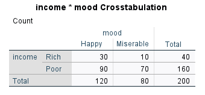

## Rule #1: Never display more than one type of percent.

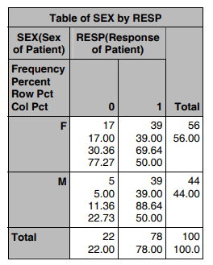

## Rule #2: Row percentages are usually best.

- Divide by row totals
- Percentages add up to 100% within each row

## Rule #3: Place the treatment/exposure variable as rows and outcome variable as columns.

- Treatment/exposure = causes
- Outcome = effects
  - Not always obvious
  - Example: gestational age

## Rule #4: If one variable has a lot more levels than the other variable, place that variable in rows.

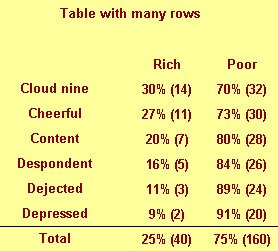

## Why is tall and thin better?

[figure not shown]

## Rule #5: Whenever you report percentages - always round.

- Two significant figures
  - Exception: close to 100% or 10% or 1%
    - 99.7832% -> 99.8%
    - 10.1417% -> 10.1%
    - 1.02067% -> 1.02%
- Don’t worry about whether your percentages add up to 99% or 101%.

## Rule #6 When in doubt, write out your table several different ways.

- The fault of default principle
- Revise your tables as often as you rewrite your text

## A simple fictitious example

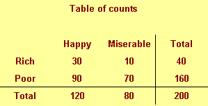

## Column percents

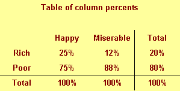

## Row percents

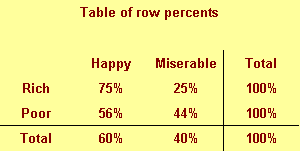

## Cell percents, 1

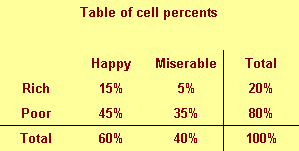

## Cell percents, 2

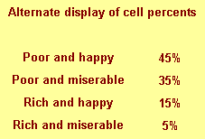

## Handling many categories

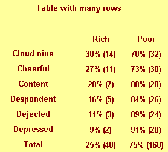

## Break #4

- What you have learned
  - Bar plots for categorical outcomes
- What’s coming next
  - R code for bar plots

## Data dictionary for gardasil, 1

```
---
data_dictionary: gardasil.csv, gardasil.tsv
```

```
source:
  This data file is part of the data
  archive for the Journal of Statistics
  Education. The entire archive is at
  http://jse.amstat.org/jse_data_archive.htm
```

```
description:
  This data set shows information about young
  women who received the Gardasil shot. Of
  particular interest is the proportion of
  women who received all three shots.
```

## Data dictionary for gardasil, 2

```
additional_description:
  http://www.amstat.org/publications/jse/v19n1/gardasil.txt
```

```
download_url:
  http://www.amstat.org/publications/jse/v19n1/gardasil.xls
  http://www.pmean.com/15/images/day2gardasil.csv
```

```
copyright:
  Unknown. You should be able to use this data for
  individual educational purposes under the Fair Use
  guidelines of U.S. copyright law.
```

```
format:
  csv: comma-delimited
  tsv: tab-delimited
```

```
varnames:
 first row of data
```

## Data dictionary for gardasil, 3

```
missing_value_code:
  not needed
```

```
size:
  rows: 1413
  columns: 10
```

## Data dictionary for gardasil, 4

```
vars:
  Age:
    label: the patient's age
    unit: years
```

```
  AgeGroup:
    label: the age group in which the patient falls
    values:
      11-17 years: 0
      18-26 years: 1
```

```
  Race:
    label: the patient's race
    values:
      white: 0
      black: 1
      Hispanic: 2
      other/unknown: 3
```

## Data dictionary for gardasil, 5

```
  Shots:
    label: the number of shots that the patients completed
```

```
  Completed:
    label: did the patient complete the three-shot regimen
    values:
      no: 0
      yes: 1
```

```
  InsuranceType:
    label: the type of insurance that the patient had
    values:
      medical assistance: 0
      private payer: 1
      hospital based [EHF]: 2
      military: 3
```

```
  MedAssist:
    label: sid the patient have some type of medical assistance
    values:
      no: 0
      yes: 1
```

## Data dictionary for gardasil, 6

```
  Location:
    label: the clinic that the patient attended
    values:
      Odenton: 1
      White Marsh: 2
      Johns Hopkins Outpatient Center: 3
      Bayview: 4
```

```
  LocationType:
    label: was the clinic in a suburban or an urban location
    values:
      suburban: 0
      urban: 1
```

```
  PracticeType:
    label: the type of practice that the patient visited
    values:
      0: pediatric
      1: family practice
      2: OB-GYN
```

## simon-5501-04-gardasil.qmd, 1

```
---
title: "Analysis of gardasil shots by demographic factors"
format:
  html:
    embed-resources: true
---

This program reads data on Gardasil vaccinations in young women. Find more information in the [data dictionary][dd].

[dd]: https://raw.githubusercontent.com/pmean/datasets/master/gardasil.yaml

The program was written by Steve Simon on 2024-09-07 and is placed in the public domain.
```

## simon-5501-04-gardasil.qmd, 2

````
## Load the tidyverse library

For most of your programs, you should load the tidyverse library. The messages and warnings are suppressed.

```{r}
#| label: setup
#| message: false
#| warning: false
library(tidyverse)
```
````

## simon-5501-04-gardasil.qmd, 3

````
## Read the data and view a brief summary

Use the read_csv function to read the data. The glimpse function will produce a brief summary. Use tolower to convert uppercase to lowercase.

```{r}
#| label: read

gard <- read_csv(
  file="../data/gardasil.csv",
  col_names=TRUE,
  col_types="nnnnnnnnnn")
names(gard) <- tolower(names(gard))
glimpse(gard)
```
````

## simon-5501-04-gardasil.qmd, 4

````
## Create factors for agegroup

The factor function identifies a variable as categorical and assigns labels to number codes. You don't necessarily need to use factor if the data you read in is character strings, as R automatically treats those variable as categorical.

```{r}
#| label: agegroup-1

gard$agegroup <- factor(
  gard$agegroup,
  levels=0:1,
  labels=c(
    "11 to 17 years",
    "18 to 26 years"))
```
````

## simon-5501-04-gardasil.qmd, 5

````
## Counts and percentages for agegroup

```{r}
#| label: agegroup-2

gard |>
  count(agegroup) |>
  mutate(total=sum(n)) |>
  mutate(pct=round(100*n/total))
```

There are roughly the same number of patients 11 to 17 years as there are patients 18 to 26 years.
````

## simon-5501-04-gardasil.qmd, 6

````
## Create factors for shots

It is a bit silly to replace 1, 2, 3 with One, Two, Three. The main reason is to clearly identify shots as categorical rather than continuous.

```{r}
#| label: shots-1

gard$shots <- factor(
  gard$shots,
  levels=1:3,
  labels=c(
    "One",
    "Two",
    "Three"))
```
````

## simon-5501-04-gardasil.qmd, 7

````
## Counts and percentages for shots

```{r}
#| label: shots-2

gard |>
  count(shots) |>
  mutate(total=sum(n)) |>
  mutate(pct=round(100*n/total))
```

Slightly more patients got three shots than one or two shots, but this is still less than half of the patients overall.
````

## simon-5501-04-gardasil.qmd, 8

````
## Compare number of shots by age group

```{r}
#| label: shots-by-age-1

gard |>
  count(agegroup, shots) |>
  group_by(agegroup) |>
  mutate(row_total=sum(n)) |>
  mutate(pct=round(100*n/row_total))
```
````

## simon-5501-04-gardasil.qmd, 9

````
## Bar chart of shots by age group

```{r}
#| label: shots-by-age-2

gard |>
  ggplot(aes(x=agegroup, fill=shots)) +
    geom_bar(position="fill") +
    xlab("Age group") +
    ylab("Proportion") +
    ggtitle("Plot drawn by Steve Simon on 2024-09-07")
```

The probability of getting all three shots was higher in the 11 to 17 year old group compared to the 18 to 26 year old group.
````

## Summary

- What you have learned
  - Scatterplots and correlations
  - Boxplots and effect sizes
  - R code for scatterplots and boxplots
  - Bar plots for categorical outcomes
  - R code for bar plots